# NBA Player Analysis – Stat 133

Brandon Pearl, Nicolas Min, Ryan Ice, and Tram Pham

11/25/2016

# Contents

1. Abstract
2. Introduction
3. Data
4. Methodology
5. Results
6. Conclusions

# Abstract

The project involves analyzing data about basketball players from the NBA League in the 2015-2016 season. The motivating question of the analysis is: âIn the 2015-2016 season, how do the skills of a player relate to his salary?â We argue that regardless of their positions, most players earn a salary which is directly correlated with their skill levels. We observe playersâ skill levels by calculating each playerâs EFF index using his basic individual statistics during the season: points, rebounds, assists, steals, clocks, turnovers, and shot attempts. Principal Components Analysis (PCA) is used to assign weight for each term in the original EFF formula. For the earned salaries during the season, we reference the released data from Basketball Referenceâs Salary reports for individual players. (From analysis of EFF index and salary of individual players, we indeed find that skill levels and salary have a direct positive relationship among the players in the NBA League).

# Introduction

In any sports league, performance of a player during the season determines his/her monetary value in the League and eventually determines his salary. In this sense, it is important to understand how closely a playerâs performance is related to his salary. Analyzing this relationship provides an understanding of how fairly and reasonably have the NBA teams have paid their players during the 2015-2016 season.

To measure each playerâs performance during the season, we adopt in this paper, the EFF or efficiency statistics, an index that is widely used to measure the performance of NBA players. EFF is derived by a simple formula: `EFF = (TP + TR + A + S + B â MFG â MFT â T) / GP`, where TP = total points, TR = total rebounds, A = assists, S = steals, b = blocks, MFG = missed field goals, MFT = missed free throws, T = turnovers, and GP = games played.

However, one of the issues with the EFF index is that it favors offense oriented players over defense oriented players, as defense players have less chance to score a goal, or catch a rebound compared to the offensive players. To compensate for this drawback, we use a modified EFF that consider the playerâs positions. We utilize Principal Components Analysis (PCA) giving weight for each term in the original EFF formula.

The modified efficiency, EFF*, is computed as: `EFF* = (w1/s1)*x1 + â¦ + (w8/s8)*x8`

We predict that this modified efficiency, EFF* have direct positive relationship with the salary that a player receives during the season. The remainder of the paper is organized as follows. In Data we briefly discuss the data table, its structure, and each variableâs significance. In Methodology we describe how we obtained and cleaned our data to fit our purpose of study and illustrates how we computed the modified EFF*. Results investigates the relationship between performance and salary from the perspective of the computed EFF*. Finally, in Conclusions we summarize our findings and point out any outstanding trends.

# Data

The National Basketball Association (NBA) is the pre-eminent men’s professional basketball league in North America, and is the premier men’s professional basketball league in the world. It has 30 teams (29 in the United States and 1 in Canada). [citation](https://en.wikipedia.org/wiki/National_Basketball_Association)

Basketball Reference.com provides professional basketball statistics updated daily for every season. The site also includes sections for coaches, awards, leaders, and the playoffs. It is one of the sites that is under Sports Reference that provide both basic and sabermetric statistics and resources for sports fans everywhere.

From the raw data files of NBA players played in 2015-2016 season provided by Basket Reference, we have created a single csv file, âroster-salary-stats.csvâ, containing all variables from Roster, Totals, and Salary, with only one column for the name of the player (the methodology of data acquisition and cleaning will be discussed in the section that follows).

In the csv file, the table contain the following variables: Player, Team, Number, Position, Height, Weight, Birth Date, Country, Experience, College, Rank Totals (within the team), Age, Games, Games Started, Minutes Played, Field Goals, Field Goal Attempts, Field Goal Percentage, 3-Point Field Goals, 3 Point Field Goal Attempts, 3 Point Field Goal Percentage, 2 Point Field Goals, 2 Point Field Goal Attempts, 2 Point Field Goal Percentage, Effective Field Goal Percentage, Free Throws, Free Throw Attempts, Free Throw Percentage, Offensive Rebounds, Defensive Rebounds, Total Rebounds, Assists, Steals, Blocks, Turnovers, Personal Fouls, Points, Points, Rank Salary (within the team), and Salary.

The data table combines three distinct data tables (roster, totals, and salary) and is sorted by the player names. As the purpose of our study is to investigate the relationship between performance and salary, the variables that derive performance index and salary are critical. Among the variables acquired from totals table, the critical variables to compute EFF index (the performance index) are Total Points, Total Rebounds, Assists, Steals, Blocks, Field Goals, Field Goal Attempts, Free Throws, Free Throw Attempts, Games (total # of games). Also, the playersâ positions, obtained from the roster table, are also critical in that we later subset the player statistics dataset by positions to calculate separate EFF indices for each position. Needless to say, salary is the most important variable in our study.

All data tables created in this project are in csv format while data summary files are in txt format.

# Methodology

## Data Acquisition

In this way, we were able to obtain all of our raw data to be process by our cleaning script.

## Data Cleaning

After acquiring the data from Basketball References, we have cleaned three distinct data tables according to the following schema: * Roster table: contains basic information about players for each team (e.g height, birth date, college,etc). We atempted to clean data in which each element in same column obtains the same standard unit or expression. For example, in Experience column, “R” means 0 year experience, so we converted R to 0 so that Experience column contains integers only. Same procedure is applied for the rest. In details, Player and College columns are kept as character. Country is abbreviated in upper case, Height is in feet and Weight is in lbs. Birth Date is in the `YYYY-MM-DD` format and all empty cells are considered as NA.  
* Stats table: contains all statistical performance data for each player. All of the columns are numeric except for Player which is character. Again, empty cells are filled with NA. * Salary table: contains the salary for each player. We converted the salary columns from `$00000` to `000000`.

After cleaning each table, we then merged the three distinct data tables- roster, totals, salary- of each team and merge them using `merge()` which also sorted them by the player names. We repeated this process for all teams and combined all teamsâ data using `rbind()`. There were some players who appeared in multiple teamsâ tables. For these players, we have used âduplicated()â function to only acquire the data from one team.  
Data cleaning produces a big data frame, called `roster-salary-stats.csv` which contains roster, stats, salary information for all teams.

## EDA

### Text Data Values (Sink’ed to file)

For the aggregated dataset, we partitioned the columns into 2 groups:

1. Qualitative data, e.g. Position
2. Quantitative data, e.g. Steals

For the qualitative data, we used dplyr to determine the frequency of each value and printed the resulting 2 column data.frame to `eda-output.txt`.

For the quantitative data, we used R’s built-in `summary()` function to generate most of the summary statistics. To get range, we simply subtract `Min.` from `Max.` in the return value from `summary()` and added it to the same result. This was then printed to the same output file, `eda-output.txt`.

### Histogram, Bar Charts, and Boxplot

After calculating descriptive summaries for quantitative variables (e.g. mean, median, min, max, std dev, range, etc) and frequencies for qualitative variables, we present the results by making histograms and boxplots for quantitative variables and bar charts for qualitative variables. For all the plots, the x-axis displays the variable (e.g college, experience, etc) and the y-axis displays the frequency of each variable. NA is also considered as one of the possibilities. For example, the bar chart for College includes NA as a school, since NA may give some information as to whether the players were recruited by the collges or otherwise.

## Data Analysis

From the cleaned âroster-salary-stats.csvâ file, first subset the data according to the playerâs position. Then add the following columns: Missed Free Throws (`Free Throws - Free Throws Attempts`), Missed Field Goals (`Field Goals â Field Goal Attempts`) and negate the number of turnovers to match our EFF formula: `EFF = (total points + total rebounds + assists + steals + blocks â missed field goals â missed free throws â turnovers) / (games played)`. From the subset of data table, select variables that are needed to compute EFF. Then, eliminate the compounding variable, ânumber of games playedâ by dividing each variable by the ânumber of games playedâ. Using `prcomp()`, compute PCA1 for each subset. Divide these weights with standard deviation of each variable, re-expressing the weights. Multiply these adjusted weights with each variable (now divided by the number of games). Sum these together to obtain EFF*.

## ShinyApp

In order to better visualize and understand the data, we built two shiny apps. The first, titled “Salary Statistics by Team”, displays a horizontal boxplot that compares the different NBA Teams’ salaries. The second, titled “Statistic Comparison for Players”, presents a scatterplot comparing a range of variables for individual players and displays the variables correlation. These apps serve as an approachable way to further analyze the data, the results of which will be discussed further in the rest of the report.

# Results

As anticipated, EFF and salary are positively correlated (r = 0.474). This result is reasonable since managers of each team will likely be paying players based on their overall skill levels. However, there are several factors that weaken the correlation.

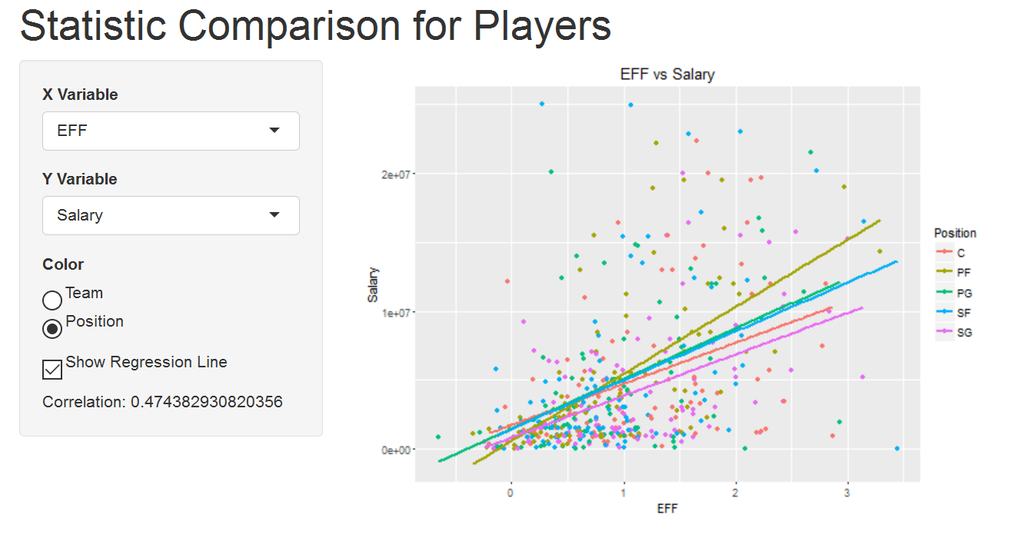

x:eff, y:salary

First, the salary of each player is determined at the beginning of the season. Even though a player may perform well for several years, 2015-2016 may be one of his worse years. In other words, because change in salary doesn’t immediately follow the change in performance, the correlation between EFF and salary is weakened. Second, salary of a player rarely goes down within a team. Therefore, players who are part of the same team for a long period of time will be paid well compared to many rookies in the team regardless of his performance during the 2015-2016 season.

Another source of compounding is player’s choice. Even if a player’s performance is better than other players who are paid more, a player might choose a team paying a little less because of preference. In other words, it is not only the financial incentives that players consider when choosing a team.

Also, in reality, the managers not only look at player’s data while drafting. They watch how each player play in the game and look at things that cannot be recorded as a data.

In addition, salary is a relative measure not an absolute measure. Said another way, there is no set monetary value per steal or per point. Rather, managers usually evaluate players based on the overall data (and sometimes intuitions) and offer a somewhat arbitrarily rounded dollar amount. We say “relative” because salary is often determined in comparison to other players in the team or in the league.

There were some interesting results regarding the correlation between several other variables.

First, experience showed relatively weak correlation with EFF (r = 0.209) which demonstrated that the years a player played in NBA cannot be used to predict his skill level.

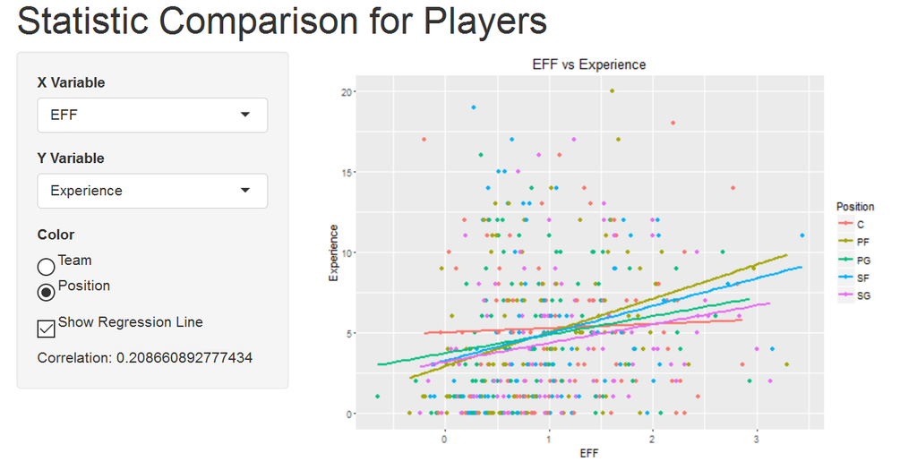

x:eff, y:experience

We suspect there are two major trends that are happening together. First, as the weak positive correlation shows, more experience in the League generally helps a player to perform better. This can be because players get used to the atmosphere and and the pressure while playing in the premiere League. However, some rookie players may perform better than the continuing players as they feel obligateded to stand out. While rookie players think playing of the NBA as a great opportunity that they do not want to let go, original players may be more relaxed with their results. We suspect this trend dampens the positive correlation between the expereince and EFF.

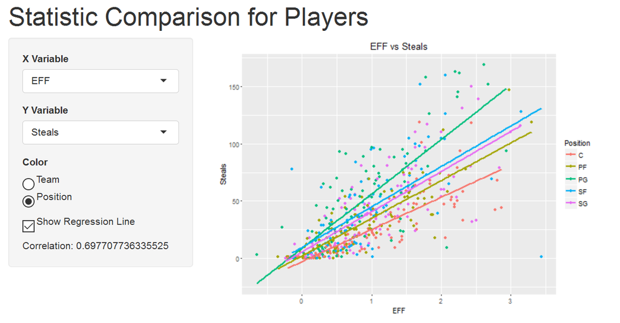

x:eff, y:steals

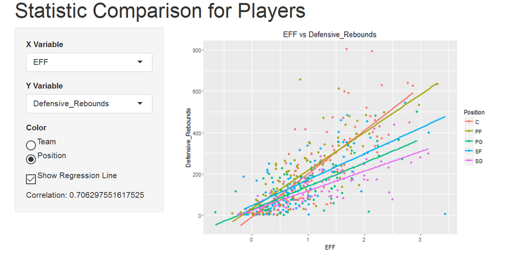

x:eff, y:defensive_rebounds

There were several notable results from EDA. Among these results, a large proportion of players did not have data for college. While it is possible that Basketball Reference left out the data, this is highly unlikely as all other variables rarely had a missing data. Basketball Reference also includes school information as long as a player has ever been matriculated as it can be observed from Jeremy Lin’s example where his school information shows Harvard University even after his graduation. Therefore, we observe that many NBA players did not go to college from the beginning.

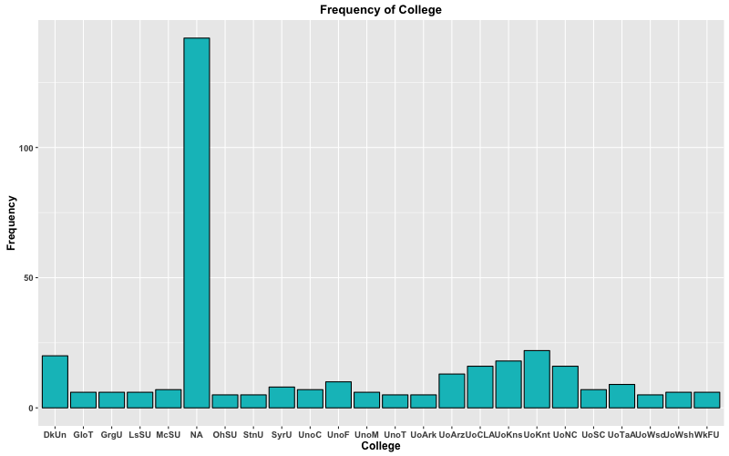

x: college, y:frequency

# Conclusions

The project shows that while there is a positive correlation between EFF and salary, it is only moderate. This data along with our calculated correlation coefficients can be valuable to members of the basketball industry. Among them, managers of each NBA team will benefit the most as they are in charge of drafting new players and determining the salaries of both rookie and continuing players.

This moderate result brings us to think there must be some other factor that managers of each team consider when determining a player’s salary. While the extent may be different from position to position, we hypothesize that, in general, the salary is highly correlated with the number of wins that players bring in to the team.

In the future, we would like to plot data for each postion and let our shiny apps compute correlation coefficient of two variables for each of the position. By comparing r value for each position, the data would be more helpful to the managers as it will help them in setting standards for each position while drafting.

In order to test our hypothesis, we are interested in the correlation between the number of wins and salary. While individual performance matters, basketball is about the team. If a player brings more wins regardless of his recorded performance, there is something about the player that brings success to each game and therefore the team.

To assist in testing the above hypothesis, we would like to gather additional measures of performance to better evaluate player efficiency. With additional performance metrics, the calculation of EFF can be fine tuned and tie closely with the number of wins that a player brings to a team. If the EFF can predict the number of wins that a player can bring, managers will have easier time evaluating players’ value and assign salaries’ accordingly.